# NKPC Persistence Data

## Preliminaries

We need to set up the two packages used - you may need to install them first.

```r
library(tidyverse)
library(DataCombine)
```

We import the BLS datasets for mining and logging, durables manufacturing and non-durables manufacturing.

```r
base_minelog <- read.table("https://download.bls.gov/pub/time.series/ce/ce.data.10a.MiningAndLogging.Employment", header = TRUE, sep = "", fill = TRUE)
base_durables <- read.table("https://download.bls.gov/pub/time.series/ce/ce.data.31a.ManufacturingDurableGoods.Employment", header = TRUE, sep = "", fill = TRUE)
base_nondurables <- read.table("https://download.bls.gov/pub/time.series/ce/ce.data.32a.ManufacturingNondurableGoods.Employment", header = TRUE, sep = "", fill = TRUE)
```

We pick the necessary time series i.e. the monthly data on “all employees in thousands”. These are the chosen time series with a CES prefix and 01 suffix.

```r
minelog <- subset(base_minelog, series_id == "CES1021100001" | series_id == "CES1021200001" | series_id == "CES1021300001" | series_id == "CES1011330001", select=c(series_id, year, period, value))

durables <- subset(base_durables, series_id == "CES3132100001" | series_id == "CES3132700001" | series_id == "CES3133100001" | series_id == "CES3133200001" | series_id == "CES3133300001" | series_id == "CES3133400001" | series_id == "CES3133500001" | series_id == "CES3133600001" | series_id == "CES3133700001" | series_id == "CES3133900001", select=c(series_id, year, period, value))

nondurables <- subset(base_nondurables, series_id == "CES3231100001" | series_id == "CES3231300001" | series_id == "CES3231400001" | series_id == "CES3231500001" | series_id == "CES3232200001" | series_id == "CES3232300001" | series_id == "CES3232400001" | series_id == "CES3232500001" | series_id == "CES3232600001" | series_id == "CES3232900001", select=c(series_id, year, period, value))
```

We then convert the months into numbers.

```r
dflist <- list(minelog, durables, nondurables)
res <- lapply(dflist, function(sector){sector$period <- gsub("M", "", sector$period) %>% as.numeric(sector$period)})

minelog$period <- res[[1]]
durables$period <- res[[2]]
nondurables$period <- res[[3]]
```

Then we aggregate the data into quarterly data.

```r
minelog$day <- rep(1,times=2232)
durables$day <- rep(1,times=4218)
nondurables$day <- rep(1,times=3750)

dflist <- list(minelog, durables, nondurables)
res <- lapply(dflist, function(sector){as.Date(paste(sector$year, sector$period, sector$day, sep="-"), "%Y-%m-%d")})

minelog$date <- res[[1]]
durables$date <- res[[2]]
nondurables$date <- res[[3]]

dflist <- list(minelog, durables, nondurables)
res <- lapply(dflist, function(sector){quarters(sector$date)})

minelog$quarter <- res[[1]]
durables$quarter <- res[[2]]
nondurables$quarter <- res[[3]]

dflist <- list(minelog, durables, nondurables)
res <- lapply(dflist, function(sector){aggregate(value ~ series_id + quarter + year, sector, sum)})

minelog <- res[[1]]
durables <- res[[2]]
nondurables <- res[[3]]
```

## Setting Up Variables of Interest

We take the natural logs of employment.

```r
minelog$logemp <- log(minelog$value)
durables$logemp <- log(durables$value)
nondurables$logemp <- log(nondurables$value)
```

We restrict the sample to between 1990 and 2019.

```r
minelog <- minelog[minelog$year > 1989 & minelog$year < 2020,]
durables <- durables[durables$year > 1989 & durables$year < 2020,]
nondurables <- nondurables[nondurables$year > 1989 & nondurables$year < 2020,]
```

We find the differences in log employment for 4, 12 and 20 quarters i.e. the growth rate of employment.

```r
dflist <- list(minelog, durables, nondurables)
res <- lapply(dflist, function(sector){sector %>% group_by(series_id) %>% mutate(logemp - lag(logemp, n = 4))})
minelog$fourth <- res[[1]]$`logemp - lag(logemp, n = 4)`
durables$fourth <- res[[2]]$`logemp - lag(logemp, n = 4)`
nondurables$fourth <- res[[3]]$`logemp - lag(logemp, n = 4)`

dflist <- list(minelog, durables, nondurables)
res <- lapply(dflist, function(sector){sector %>% group_by(series_id) %>% mutate(logemp - lag(logemp, n = 12))})
minelog$twelth <- res[[1]]$`logemp - lag(logemp, n = 12)`
durables$twelth <- res[[2]]$`logemp - lag(logemp, n = 12)`
nondurables$twelth <- res[[3]]$`logemp - lag(logemp, n = 12)`

dflist <- list(minelog, durables, nondurables)
res <- lapply(dflist, function(sector){sector %>% group_by(series_id) %>% mutate(logemp - lag(logemp, n = 20))})
minelog$twentieth <- res[[1]]$`logemp - lag(logemp, n = 20)`
durables$twentieth <- res[[2]]$`logemp - lag(logemp, n = 20)`
nondurables$twentieth <- res[[3]]$`logemp - lag(logemp, n = 20)`
```

## Regressions

We regress the 4th/12th/20th difference of log employment by each mining/logging series against its 1st lag.

```r
ml_d4l1 <- by(data = minelog, minelog$series_id, function(subset){lm(fourth ~ lag(fourth), subset)}) %>% sapply(., coef) %>% as.data.frame(.,row.names = c("Intercept","D4L1")) %>% .[-1,1:4] %>% pivot_longer(c("CES1021100001","CES1021200001","CES1021300001","CES1011330001"), names_to = "series", values_to = "D4L1")

ml_d12l1 <- by(data = minelog, minelog$series_id, function(subset){lm(twelth ~ lag(twelth), subset)}) %>% sapply(., coef) %>% as.data.frame(.,row.names = c("Intercept","D12L1")) %>% .[-1,1:4] %>% pivot_longer(c("CES1021100001","CES1021200001","CES1021300001","CES1011330001"), names_to = "series", values_to = "D12L1")

ml_d20l1 <- by(data = minelog, minelog$series_id, function(subset){lm(twentieth ~ lag(twentieth), subset)}) %>% sapply(., coef) %>% as.data.frame(.,row.names = c("Intercept","D20L1")) %>% .[-1,1:4] %>% pivot_longer(c("CES1021100001","CES1021200001","CES1021300001","CES1011330001"), names_to = "series", values_to = "D20L1")
```

We regress the 4th/12th/20th difference of log employment by each durables series against its 1st lag.

```r
d_d4l1 <- by(data = durables, durables$series_id, function(subset){lm(fourth ~ lag(fourth), subset)}) %>% sapply(., coef) %>% as.data.frame(.,row.names = c("Intercept","D4L1")) %>% .[-1,1:10] %>% pivot_longer(c("CES3132100001", "CES3132700001", "CES3133100001", "CES3133200001", "CES3133300001", "CES3133400001", "CES3133500001", "CES3133600001", "CES3133700001", "CES3133900001"), names_to = "series", values_to = "D4L1")

d_d12l1 <- by(data = durables, durables$series_id, function(subset){lm(twelth ~ lag(twelth), subset)}) %>% sapply(., coef) %>% as.data.frame(.,row.names = c("Intercept","D12L1")) %>% .[-1,1:10] %>% pivot_longer(c("CES3132100001", "CES3132700001", "CES3133100001", "CES3133200001", "CES3133300001", "CES3133400001", "CES3133500001", "CES3133600001", "CES3133700001", "CES3133900001"), names_to = "series", values_to = "D12L1")

d_d20l1 <- by(data = durables, durables$series_id, function(subset){lm(twentieth ~ lag(twentieth), subset)}) %>% sapply(., coef) %>% as.data.frame(.,row.names = c("Intercept","D20L1")) %>% .[-1,1:10] %>% pivot_longer(c("CES3132100001", "CES3132700001", "CES3133100001", "CES3133200001", "CES3133300001", "CES3133400001", "CES3133500001", "CES3133600001", "CES3133700001", "CES3133900001"), names_to = "series", values_to = "D20L1")
```

We regress the 4th/12th/20th difference of log employment by each nondurables series against its 1st lag.

```r
nd_d4l1 <- by(data = nondurables, nondurables$series_id, function(subset){lm(fourth ~ lag(fourth), subset)}) %>% sapply(., coef) %>% as.data.frame(.,row.names = c("Intercept","D4L1")) %>% .[-1,1:10] %>% pivot_longer(c("CES3231100001", "CES3231300001", "CES3231400001", "CES3231500001", "CES3232200001", "CES3232300001", "CES3232400001", "CES3232500001", "CES3232600001", "CES3232900001"), names_to = "series", values_to = "D4L1")

nd_d12l1 <- by(data = nondurables, nondurables$series_id, function(subset){lm(twelth ~ lag(twelth), subset)}) %>% sapply(., coef) %>% as.data.frame(.,row.names = c("Intercept","D12L1")) %>% .[-1,1:10] %>% pivot_longer(c("CES3231100001", "CES3231300001", "CES3231400001", "CES3231500001", "CES3232200001", "CES3232300001", "CES3232400001", "CES3232500001", "CES3232600001", "CES3232900001"), names_to = "series", values_to = "D12L1")

nd_d20l1 <- by(data = nondurables, nondurables$series_id, function(subset){lm(twentieth ~ lag(twentieth), subset)}) %>% sapply(., coef) %>% as.data.frame(.,row.names = c("Intercept","D20L1")) %>% .[-1,1:10] %>% pivot_longer(c("CES3231100001", "CES3231300001", "CES3231400001", "CES3231500001", "CES3232200001", "CES3232300001", "CES3232400001", "CES3232500001", "CES3232600001", "CES3232900001"), names_to = "series", values_to = "D20L1")
```

We regress the 4th/12th/20th difference of log employment by each mining/logging series against its 4th lag.

```r
ml_d4l4 <- by(data = minelog, minelog$series_id, function(subset){lm(fourth ~ lag(fourth, n=4), subset)}) %>% sapply(., coef) %>% as.data.frame(.,row.names = c("Intercept","D4L4")) %>% .[-1,1:4] %>% pivot_longer(c("CES1021100001","CES1021200001","CES1021300001","CES1011330001"), names_to = "series", values_to = "D4L4")

ml_d12l4 <- by(data = minelog, minelog$series_id, function(subset){lm(twelth ~ lag(twelth, n=4), subset)}) %>% sapply(., coef) %>% as.data.frame(.,row.names = c("Intercept","D4L4")) %>% .[-1,1:4] %>% pivot_longer(c("CES1021100001","CES1021200001","CES1021300001","CES1011330001"), names_to = "series", values_to = "D12L4")

ml_d20l4 <- by(data = minelog, minelog$series_id, function(subset){lm(twentieth ~ lag(twentieth, n=4), subset)}) %>% sapply(., coef) %>% as.data.frame(.,row.names = c("Intercept","D4L4")) %>% .[-1,1:4] %>% pivot_longer(c("CES1021100001","CES1021200001","CES1021300001","CES1011330001"), names_to = "series", values_to = "D20L4")
```

We regress the 4th/12th/20th difference of log employment by each durables series against its 4th lag.

```r
d_d4l4 <- by(data = durables, durables$series_id, function(subset){lm(fourth ~ lag(fourth, n=4), subset)}) %>% sapply(., coef) %>% as.data.frame(.,row.names = c("Intercept","D4L4")) %>% .[-1,1:10] %>% pivot_longer(c("CES3132100001", "CES3132700001", "CES3133100001", "CES3133200001", "CES3133300001", "CES3133400001", "CES3133500001", "CES3133600001", "CES3133700001", "CES3133900001"), names_to = "series", values_to = "D4L4")

d_d12l4 <- by(data = durables, durables$series_id, function(subset){lm(twelth ~ lag(twelth, n=4), subset)}) %>% sapply(., coef) %>% as.data.frame(.,row.names = c("Intercept","D12L4")) %>% .[-1,1:10] %>% pivot_longer(c("CES3132100001", "CES3132700001", "CES3133100001", "CES3133200001", "CES3133300001", "CES3133400001", "CES3133500001", "CES3133600001", "CES3133700001", "CES3133900001"), names_to = "series", values_to = "D12L4")

d_d20l4 <- by(data = durables, durables$series_id, function(subset){lm(twentieth ~ lag(twentieth, n=4), subset)}) %>% sapply(., coef) %>% as.data.frame(.,row.names = c("Intercept","D20L4")) %>% .[-1,1:10] %>% pivot_longer(c("CES3132100001", "CES3132700001", "CES3133100001", "CES3133200001", "CES3133300001", "CES3133400001", "CES3133500001", "CES3133600001", "CES3133700001", "CES3133900001"), names_to = "series", values_to = "D20L4")
```

We regress the 4th/12th/20th difference of log employment by each nondurables series against its 4th lag.

```r
nd_d4l4 <- by(data = nondurables, nondurables$series_id, function(subset){lm(fourth ~ lag(fourth, n=4), subset)}) %>% sapply(., coef) %>% as.data.frame(.,row.names = c("Intercept","D4L4")) %>% .[-1,1:10] %>% pivot_longer(c("CES3231100001", "CES3231300001", "CES3231400001", "CES3231500001", "CES3232200001", "CES3232300001", "CES3232400001", "CES3232500001", "CES3232600001", "CES3232900001"), names_to = "series", values_to = "D4L4")

nd_d12l4 <- by(data = nondurables, nondurables$series_id, function(subset){lm(twelth ~ lag(twelth, n=4), subset)}) %>% sapply(., coef) %>% as.data.frame(.,row.names = c("Intercept","D12L4")) %>% .[-1,1:10] %>% pivot_longer(c("CES3231100001", "CES3231300001", "CES3231400001", "CES3231500001", "CES3232200001", "CES3232300001", "CES3232400001", "CES3232500001", "CES3232600001", "CES3232900001"), names_to = "series", values_to = "D12L4")

nd_d20l4 <- by(data = nondurables, nondurables$series_id, function(subset){lm(twentieth ~ lag(twentieth, n=4), subset)}) %>% sapply(., coef) %>% as.data.frame(.,row.names = c("Intercept","D20L4")) %>% .[-1,1:10] %>% pivot_longer(c("CES3231100001", "CES3231300001", "CES3231400001", "CES3231500001", "CES3232200001", "CES3232300001", "CES3232400001", "CES3232500001", "CES3232600001", "CES3232900001"), names_to = "series", values_to = "D20L4")
```

We regress the 4th/12th/20th difference of log employment by each mining/logging series against its 8 lags.

```r
ml_d4l8 <- by(data = minelog, minelog$series_id, function(subset){lm(fourth ~ lag(fourth) + lag(fourth, n = 2) + + lag(fourth, n = 3) + lag(fourth, n = 4) + lag(fourth, n = 5) + lag(fourth, n = 6) + lag(fourth, n = 7) + lag(fourth, n = 8), subset)}) %>% sapply(., coef) %>% as.data.frame(., row.names = c("Intercept",1,2,3,4,5,6,7,8)) %>% .[-1,1:4] %>% bind_rows(., colSums(.)) %>% .[-c(1:8), 1:4] %>% pivot_longer(c("CES1021100001","CES1021200001","CES1021300001","CES1011330001"), names_to = "series", values_to = "D4L8")

ml_d12l8 <- by(data = minelog, minelog$series_id, function(subset){lm(twelth ~ lag(twelth) + lag(twelth, n = 2) + + lag(twelth, n = 3) + lag(twelth, n = 4) + lag(twelth, n = 5) + lag(twelth, n = 6) + lag(twelth, n = 7) + lag(twelth, n = 8), subset)}) %>% sapply(., coef) %>% as.data.frame(., row.names = c("Intercept",1,2,3,4,5,6,7,8)) %>% .[-1,1:4] %>% bind_rows(., colSums(.)) %>% .[-c(1:8), 1:4] %>% pivot_longer(c("CES1021100001","CES1021200001","CES1021300001","CES1011330001"), names_to = "series", values_to = "D12L8")

ml_d20l8 <- by(data = minelog, minelog$series_id, function(subset){lm(twentieth ~ lag(twentieth) + lag(twentieth, n = 2) + + lag(twentieth, n = 3) + lag(twentieth, n = 4) + lag(twentieth, n = 5) + lag(twentieth, n = 6) + lag(twentieth, n = 7) + lag(twentieth, n = 8), subset)}) %>% sapply(., coef) %>% as.data.frame(., row.names = c("Intercept",1,2,3,4,5,6,7,8)) %>% .[-1,1:4] %>% bind_rows(., colSums(.)) %>% .[-c(1:8), 1:4] %>% pivot_longer(c("CES1021100001","CES1021200001","CES1021300001","CES1011330001"), names_to = "series", values_to = "D20L8")
```

We regress the 4th/12th/20th difference of log employment by each durables series against its 8 lags.

```r
d_d4l8 <- by(data = durables, durables$series_id, function(subset){lm(fourth ~ lag(fourth) + lag(fourth, n = 2) + + lag(fourth, n = 3) + lag(fourth, n = 4) + lag(fourth, n = 5) + lag(fourth, n = 6) + lag(fourth, n = 7) + lag(fourth, n = 8), subset)}) %>% sapply(., coef) %>% as.data.frame(., row.names = c("Intercept",1,2,3,4,5,6,7,8)) %>% .[-1,1:10] %>% bind_rows(., colSums(.)) %>% .[-c(1:8), 1:10] %>% pivot_longer(c("CES3132100001", "CES3132700001", "CES3133100001", "CES3133200001", "CES3133300001", "CES3133400001", "CES3133500001", "CES3133600001", "CES3133700001", "CES3133900001"), names_to = "series", values_to = "D4L8")

d_d12l8 <- by(data = durables, durables$series_id, function(subset){lm(twelth ~ lag(twelth) + lag(twelth, n = 2) + + lag(twelth, n = 3) + lag(twelth, n = 4) + lag(twelth, n = 5) + lag(twelth, n = 6) + lag(twelth, n = 7) + lag(twelth, n = 8), subset)}) %>% sapply(., coef) %>% as.data.frame(., row.names = c("Intercept",1,2,3,4,5,6,7,8)) %>% .[-1,1:10] %>% bind_rows(., colSums(.)) %>% .[-c(1:8), 1:10] %>% pivot_longer(c("CES3132100001", "CES3132700001", "CES3133100001", "CES3133200001", "CES3133300001", "CES3133400001", "CES3133500001", "CES3133600001", "CES3133700001", "CES3133900001"), names_to = "series", values_to = "D12L8")

d_d20l8 <- by(data = durables, durables$series_id, function(subset){lm(twentieth ~ lag(twentieth) + lag(twentieth, n = 2) + + lag(twentieth, n = 3) + lag(twentieth, n = 4) + lag(twentieth, n = 5) + lag(twentieth, n = 6) + lag(twentieth, n = 7) + lag(twentieth, n = 8), subset)}) %>% sapply(., coef) %>% as.data.frame(., row.names = c("Intercept",1,2,3,4,5,6,7,8)) %>% .[-1,1:10] %>% bind_rows(., colSums(.)) %>% .[-c(1:8), 1:10] %>% pivot_longer(c("CES3132100001", "CES3132700001", "CES3133100001", "CES3133200001", "CES3133300001", "CES3133400001", "CES3133500001", "CES3133600001", "CES3133700001", "CES3133900001"), names_to = "series", values_to = "D20L8")
```

We regress the 4th/12th/20th difference of log employment by each nondurables series against 8 lags.

```r
nd_d4l8 <- by(data = nondurables, nondurables$series_id, function(subset){lm(fourth ~ lag(fourth) + lag(fourth, n = 2) + + lag(fourth, n = 3) + lag(fourth, n = 4) + lag(fourth, n = 5) + lag(fourth, n = 6) + lag(fourth, n = 7) + lag(fourth, n = 8), subset)}) %>% sapply(., coef) %>% as.data.frame(., row.names = c("Intercept",1,2,3,4,5,6,7,8)) %>% .[-1,1:10] %>% bind_rows(., colSums(.)) %>% .[-c(1:8), 1:10] %>% pivot_longer(c("CES3231100001", "CES3231300001", "CES3231400001", "CES3231500001", "CES3232200001", "CES3232300001", "CES3232400001", "CES3232500001", "CES3232600001", "CES3232900001"), names_to = "series", values_to = "D4L8")

nd_d12l8 <- by(data = nondurables, nondurables$series_id, function(subset){lm(twelth ~ lag(twelth) + lag(twelth, n = 2) + + lag(twelth, n = 3) + lag(twelth, n = 4) + lag(twelth, n = 5) + lag(twelth, n = 6) + lag(twelth, n = 7) + lag(twelth, n = 8), subset)}) %>% sapply(., coef) %>% as.data.frame(., row.names = c("Intercept",1,2,3,4,5,6,7,8)) %>% .[-1,1:10] %>% bind_rows(., colSums(.)) %>% .[-c(1:8), 1:10] %>% pivot_longer(c("CES3231100001", "CES3231300001", "CES3231400001", "CES3231500001", "CES3232200001", "CES3232300001", "CES3232400001", "CES3232500001", "CES3232600001", "CES3232900001"), names_to = "series", values_to = "D12L8")

nd_d20l8 <- by(data = nondurables, nondurables$series_id, function(subset){lm(twentieth ~ lag(twentieth) + lag(twentieth, n = 2) + + lag(twentieth, n = 3) + lag(twentieth, n = 4) + lag(twentieth, n = 5) + lag(twentieth, n = 6) + lag(twentieth, n = 7) + lag(twentieth, n = 8), subset)}) %>% sapply(., coef) %>% as.data.frame(., row.names = c("Intercept",1,2,3,4,5,6,7,8)) %>% .[-1,1:10] %>% bind_rows(., colSums(.)) %>% .[-c(1:8), 1:10] %>% pivot_longer(c("CES3231100001", "CES3231300001", "CES3231400001", "CES3231500001", "CES3232200001", "CES3232300001", "CES3232400001", "CES3232500001", "CES3232600001", "CES3232900001"), names_to = "series", values_to = "D20L8")
```

## Aggregation of Data

We aggregate all the regression coefficients.

```r
mlcoefs <- merge(ml_d4l1, ml_d4l4)
mlcoefs <- merge(mlcoefs, ml_d4l8)
mlcoefs <- merge(mlcoefs, ml_d12l1)
mlcoefs <- merge(mlcoefs, ml_d12l4)
mlcoefs <- merge(mlcoefs, ml_d12l8)
mlcoefs <- merge(mlcoefs, ml_d20l1)
mlcoefs <- merge(mlcoefs, ml_d20l4)
mlcoefs <- merge(mlcoefs, ml_d20l8)
mlcoefs <- bind_cols(mlcoefs,c(rep("minelog",4))) %>% rename(sector = ...11)
```

```
## * NA -> ...11
```

```r
dcoefs <- merge(d_d4l1, d_d4l4)
dcoefs <- merge(dcoefs, d_d4l8)
dcoefs <- merge(dcoefs, d_d12l1)
dcoefs <- merge(dcoefs, d_d12l4)
dcoefs <- merge(dcoefs, d_d12l8)
dcoefs <- merge(dcoefs, d_d20l1)
dcoefs <- merge(dcoefs, d_d20l4)
dcoefs <- merge(dcoefs, d_d20l8)
dcoefs <- bind_cols(dcoefs,c(rep("durables",10))) %>% rename(sector = ...11)
```

```
## * NA -> ...11
```

```r
ndcoefs <- merge(nd_d4l1, nd_d4l4)
ndcoefs <- merge(ndcoefs, nd_d4l8)
ndcoefs <- merge(ndcoefs, nd_d12l1)
ndcoefs <- merge(ndcoefs, nd_d12l4)
ndcoefs <- merge(ndcoefs, nd_d12l8)
ndcoefs <- merge(ndcoefs, nd_d20l1)
ndcoefs <- merge(ndcoefs, nd_d20l4)
ndcoefs <- merge(ndcoefs, nd_d20l8)
ndcoefs <- bind_cols(ndcoefs,c(rep("nondurables",10))) %>% rename(sector = ...11)
```

```
## * NA -> ...11
```

```r
allcoefs <- bind_rows(dcoefs, ndcoefs)
allcoefs <- bind_rows(allcoefs, mlcoefs)
```

We replace the series_id with two digit codes which are easier to read.

```r
replaceData <- data.frame(from = c("CES1021100001", "CES1021200001", "CES1021300001", "CES1011330001","CES3132100001", "CES3132700001", "CES3133100001", "CES3133200001", "CES3133300001", "CES3133400001", "CES3133500001", "CES3133600001", "CES3133700001", "CES3133900001","CES3231100001", "CES3231300001", "CES3231400001", "CES3231500001", "CES3232200001", "CES3232300001", "CES3232400001", "CES3232500001", "CES3232600001", "CES3232900001"), to = c("OG","MX","SM","LG","WD","NM","PM","FM","MC","CE","EE","TR","FN","MD","FO","TX","TP","AP","PP","PR","PT","CH","PL","MN"))

allcoefs <- FindReplace(data = allcoefs, Var = "series", replaceData, from = "from", to = "to")
```

```
## Only exact matches will be replaced.
```

```r
allcoefs2 <- allcoefs %>% pivot_longer(c("D4L1","D4L4","D4L8","D12L1","D12L4","D12L8","D20L1","D20L4","D20L8"), names_to = "measure", values_to = "persistence")
```

## Index

The conversion is given by the following table.

```r
index <- data.frame(c("CES1021100001", "CES1021200001", "CES1021300001", "CES1011330001","CES3132100001", "CES3132700001", "CES3133100001", "CES3133200001", "CES3133300001", "CES3133400001", "CES3133500001", "CES3133600001", "CES3133700001", "CES3133900001","CES3231100001", "CES3231300001", "CES3231400001", "CES3231500001", "CES3232200001", "CES3232300001", "CES3232400001", "CES3232500001", "CES3232600001", "CES3232900001"),c("Oil and gas extraction","Mining, except oil and gas","Support activities for mining","Logging","Wood products","Nonmetallic mineral products","Primary metals","Fabricated metal products","Machinery","Computer and electronic products","Electrical equipment and appliances","Transportation equipment","Furniture and related products","Miscellaneous durable goods manufacturing","Food manufacturing","Textile mills","Textile product mills","Apparel","Paper and paper products","Printing and related support activities","Petroleum and coal products","Chemicals","Plastics and rubber products","Miscellaneous nondurable goods manufacturing"), c("OG","MX","SM","LG","WD","NM","PM","FM","MC","CE","EE","TR","FN","MD","FO","TX","TP","AP","PP","PR","PT","CH","PL","MN")) %>% `colnames<-`(.,c("series","description","shorthand"))

index
```

```
##           series                                  description shorthand
## 1  CES1021100001                       Oil and gas extraction        OG
## 2  CES1021200001                   Mining, except oil and gas        MX
## 3  CES1021300001                Support activities for mining        SM
## 4  CES1011330001                                      Logging        LG
## 5  CES3132100001                                Wood products        WD
## 6  CES3132700001                 Nonmetallic mineral products        NM
## 7  CES3133100001                               Primary metals        PM
## 8  CES3133200001                    Fabricated metal products        FM
## 9  CES3133300001                                    Machinery        MC
## 10 CES3133400001             Computer and electronic products        CE
## 11 CES3133500001          Electrical equipment and appliances        EE
## 12 CES3133600001                     Transportation equipment        TR
## 13 CES3133700001               Furniture and related products        FN
## 14 CES3133900001    Miscellaneous durable goods manufacturing        MD
## 15 CES3231100001                           Food manufacturing        FO
## 16 CES3231300001                                Textile mills        TX
## 17 CES3231400001                        Textile product mills        TP
## 18 CES3231500001                                      Apparel        AP
## 19 CES3232200001                     Paper and paper products        PP
## 20 CES3232300001      Printing and related support activities        PR
## 21 CES3232400001                  Petroleum and coal products        PT
## 22 CES3232500001                                    Chemicals        CH
## 23 CES3232600001                 Plastics and rubber products        PL
## 24 CES3232900001 Miscellaneous nondurable goods manufacturing        MN
```

## Diagrams

### 1 year growth rate regressed against 1st/4th/8 lag (together)

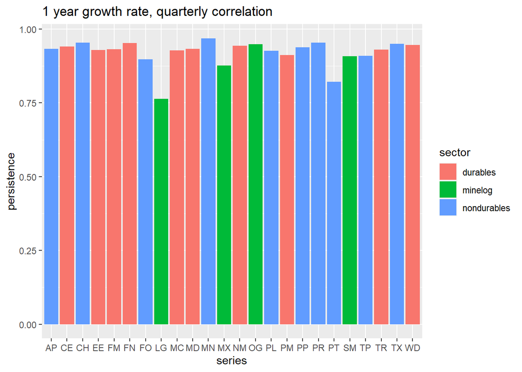

```r
p1a <- allcoefs2 %>% filter(measure == "D4L1") %>% ggplot(aes(x = series, y = persistence, fill = sector)) + geom_col() + labs(title = "1 year growth rate, quarterly correlation")
p1a
```

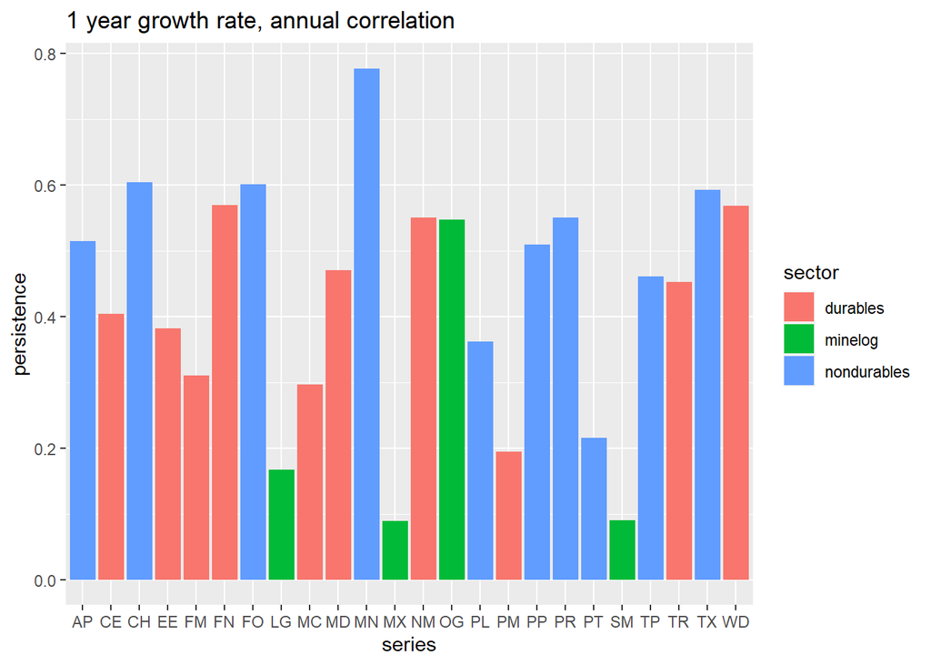

```r
p2a <- allcoefs2 %>% filter(measure == "D4L4") %>% ggplot(aes(x = series, y = persistence, fill = sector)) + geom_col() + labs(title = "1 year growth rate, annual correlation")
p2a
```

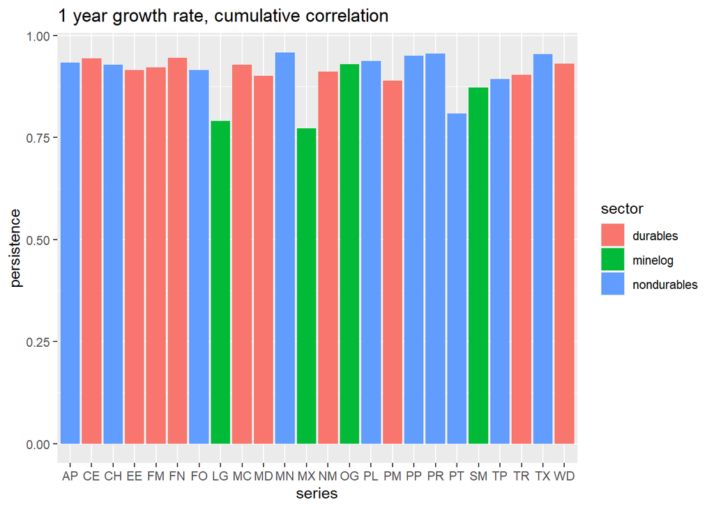

```r
p3a <- allcoefs2 %>% filter(measure == "D4L8") %>% ggplot(aes(x = series, y = persistence, fill = sector)) + geom_col() + labs(title = "1 year growth rate, cumulative correlation")
p3a
```

### 3 year growth rate regressed against 1st/4th/8 lag (together)

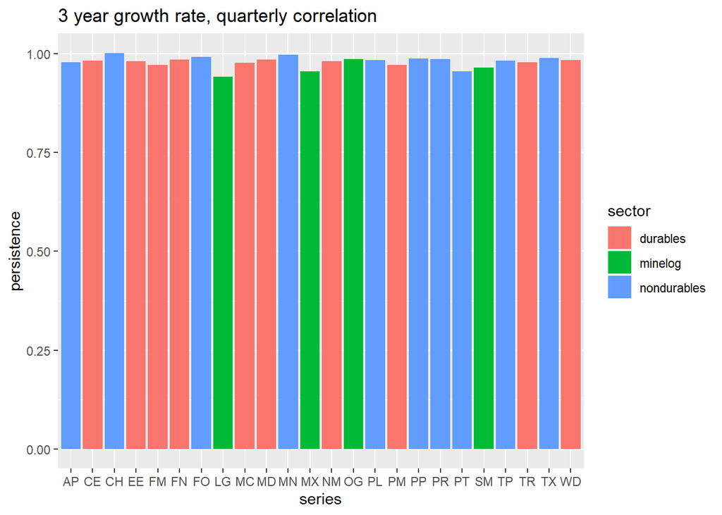

```r
p4a <- allcoefs2 %>% filter(measure == "D12L1") %>% ggplot(aes(x = series, y = persistence, fill = sector)) + geom_col() + labs(title = "3 year growth rate, quarterly correlation")
p4a
```

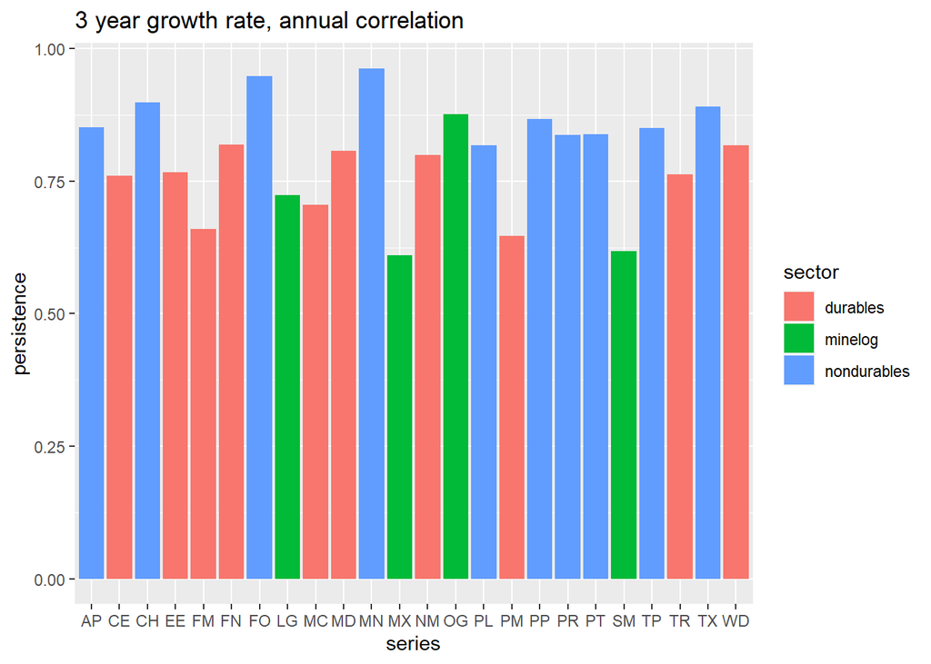

```r
p5a <- allcoefs2 %>% filter(measure == "D12L4") %>% ggplot(aes(x = series, y = persistence, fill = sector)) + geom_col() + labs(title = "3 year growth rate, annual correlation")
p5a
```

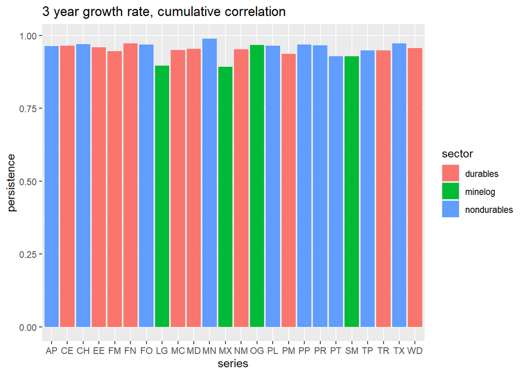

```r
p6a <- allcoefs2 %>% filter(measure == "D12L8") %>% ggplot(aes(x = series, y = persistence, fill = sector)) + geom_col() + labs(title = "3 year growth rate, cumulative correlation")
p6a
```

### 5 year growth rate regressed against 1st/4th/8 lag (together)

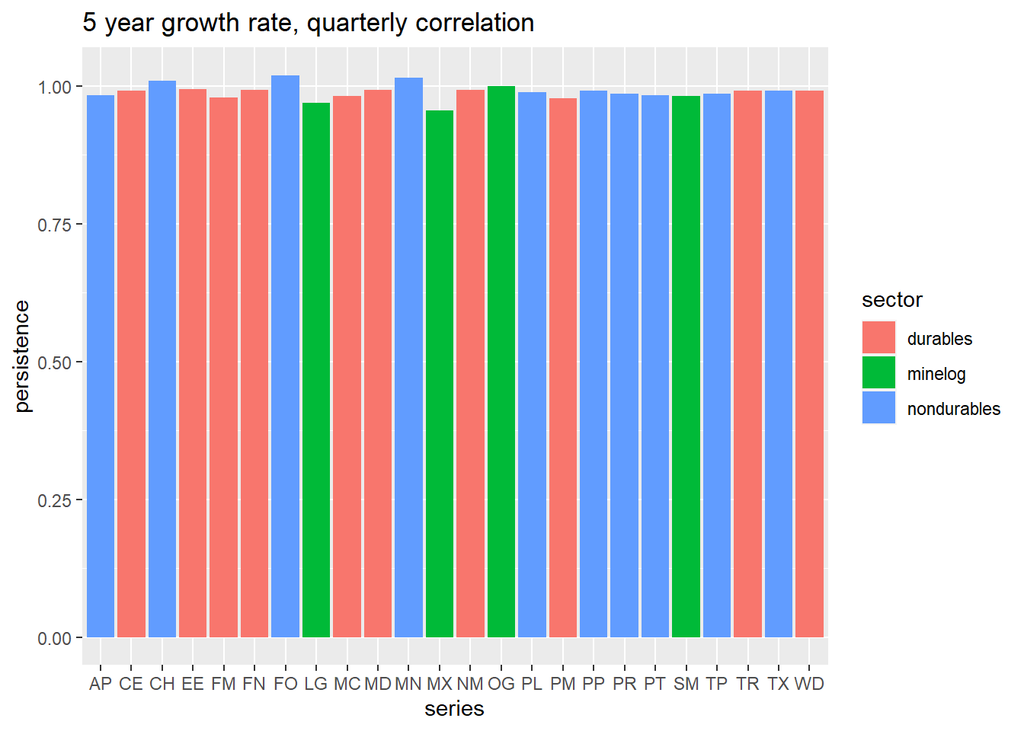

```r
p7a <- allcoefs2 %>% filter(measure == "D20L1") %>% ggplot(aes(x = series, y = persistence, fill = sector)) + geom_col() + labs(title = "5 year growth rate, quarterly correlation")
p7a
```

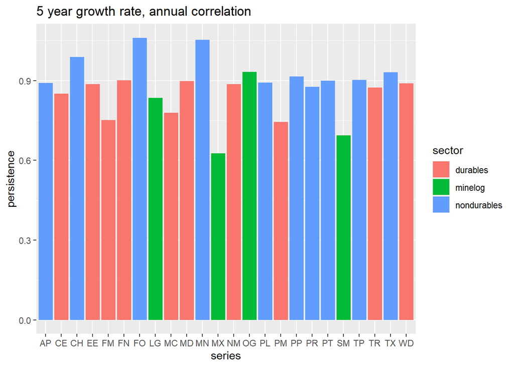

```r
p8a <- allcoefs2 %>% filter(measure == "D20L4") %>% ggplot(aes(x = series, y = persistence, fill = sector)) + geom_col() + labs(title = "5 year growth rate, annual correlation")
p8a
```

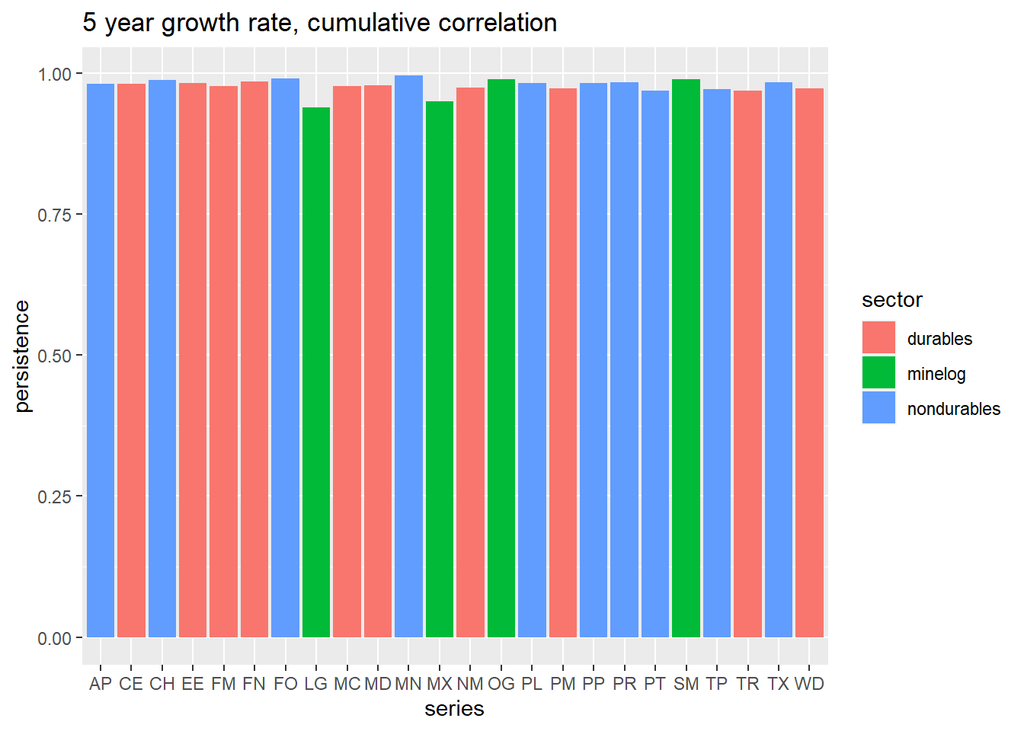

```r
p9a <- allcoefs2 %>% filter(measure == "D20L8") %>% ggplot(aes(x = series, y = persistence, fill = sector)) + geom_col() + labs(title = "5 year growth rate, cumulative correlation")
p9a
```

### 1 year growth rate regressed against 1st/4th/8 lag (split)

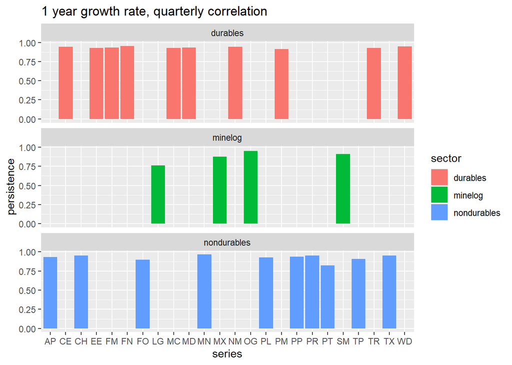

```r
p1b <- allcoefs2 %>% filter(measure == "D4L1") %>% ggplot(aes(x = series, y = persistence, fill = sector)) + geom_col() + labs(title = "1 year growth rate, quarterly correlation") + facet_wrap(~ sector, nrow = 3)
p1b
```

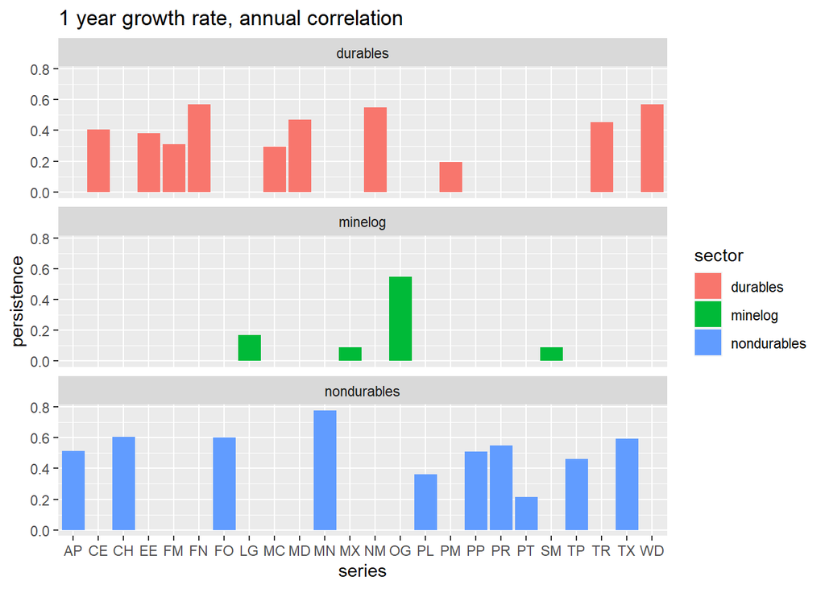

```r
p2b <- allcoefs2 %>% filter(measure == "D4L4") %>% ggplot(aes(x = series, y = persistence, fill = sector)) + geom_col() + labs(title = "1 year growth rate, annual correlation") + facet_wrap(~ sector, nrow = 3)
p2b
```

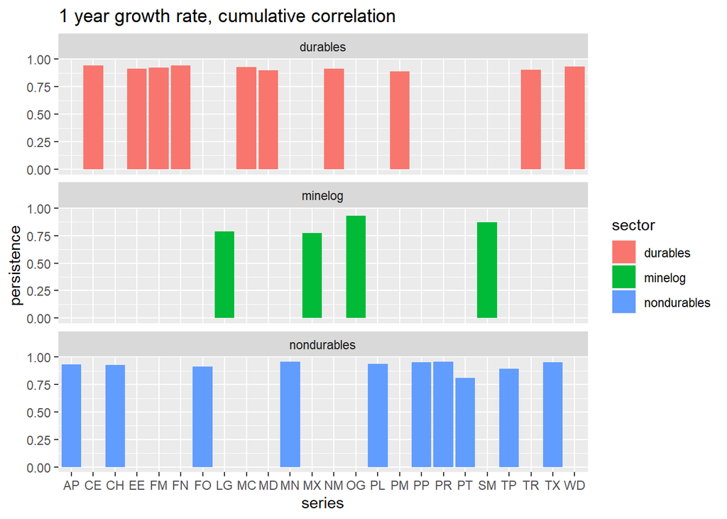

```r
p3b <- allcoefs2 %>% filter(measure == "D4L8") %>% ggplot(aes(x = series, y = persistence, fill = sector)) + geom_col() + labs(title = "1 year growth rate, cumulative correlation") + facet_wrap(~ sector, nrow = 3)
p3b
```

### 3 year growth rate regressed against 1st/4th/8 lag (split)

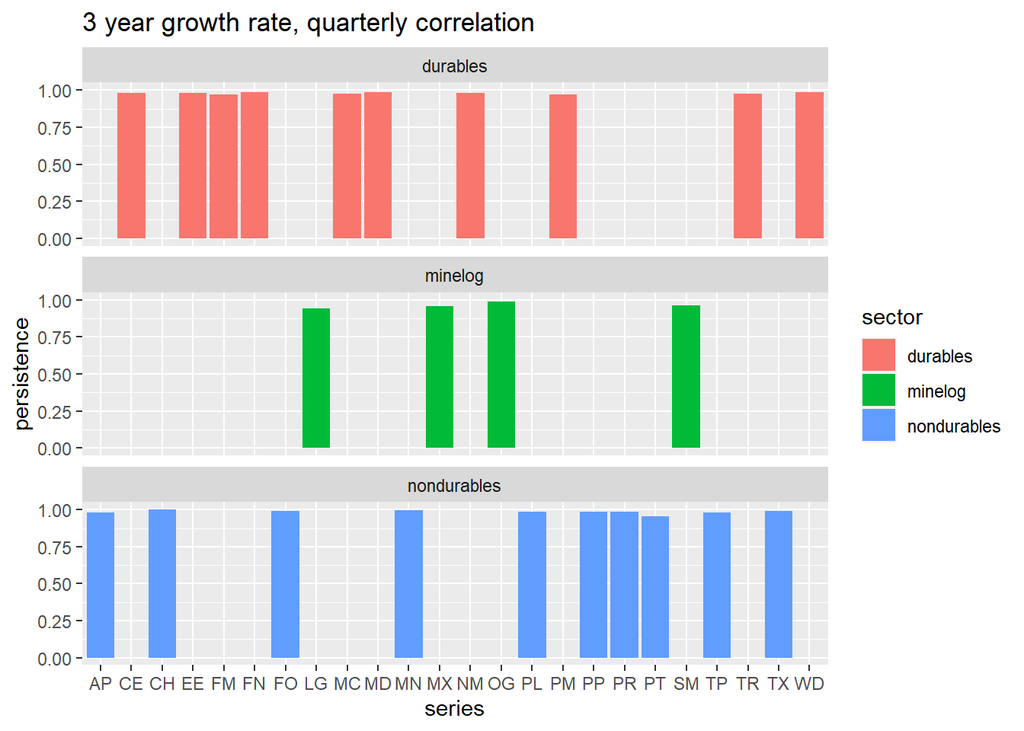

```r
p4b <- allcoefs2 %>% filter(measure == "D12L1") %>% ggplot(aes(x = series, y = persistence, fill = sector)) + geom_col() + labs(title = "3 year growth rate, quarterly correlation") + facet_wrap(~ sector, nrow = 3)
p4b
```

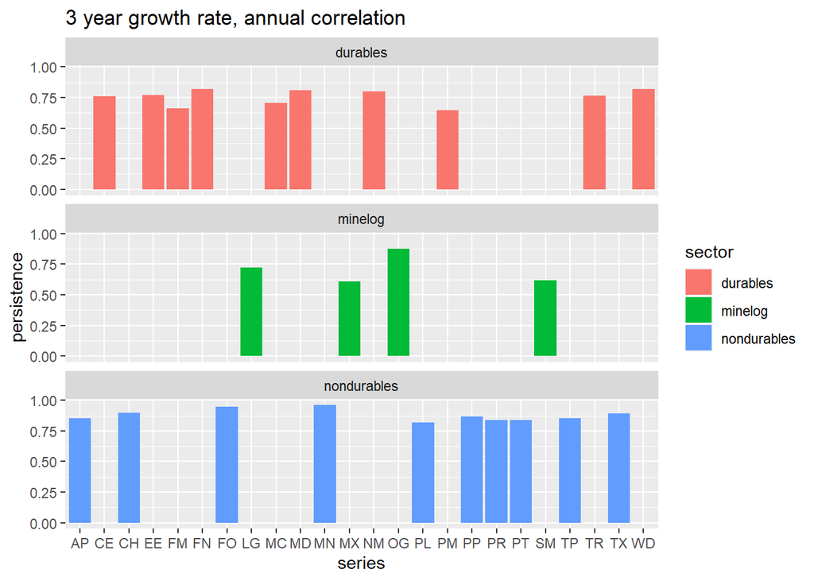

```r
p5b <- allcoefs2 %>% filter(measure == "D12L4") %>% ggplot(aes(x = series, y = persistence, fill = sector)) + geom_col() + labs(title = "3 year growth rate, annual correlation") + facet_wrap(~ sector, nrow = 3)
p5b
```

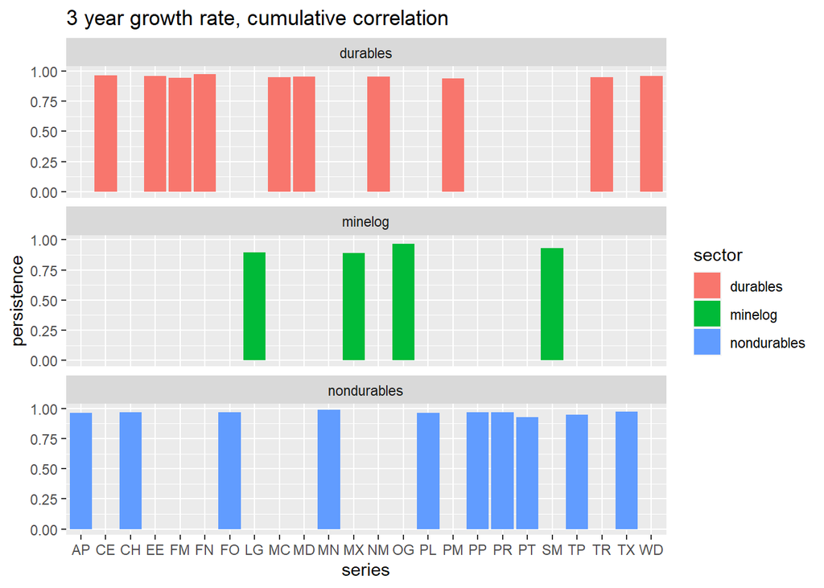

```r
p6b <- allcoefs2 %>% filter(measure == "D12L8") %>% ggplot(aes(x = series, y = persistence, fill = sector)) + geom_col() + labs(title = "3 year growth rate, cumulative correlation") + facet_wrap(~ sector, nrow = 3)
p6b
```

### 5 year growth rate regressed against 1st/4th/8 lag (split)

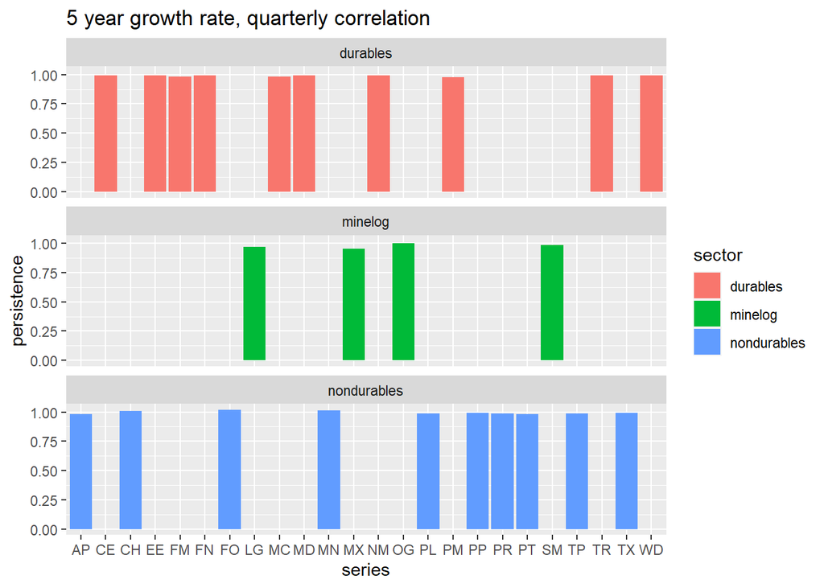

```r
p7b <- allcoefs2 %>% filter(measure == "D20L1") %>% ggplot(aes(x = series, y = persistence, fill = sector)) + geom_col() + labs(title = "5 year growth rate, quarterly correlation") + facet_wrap(~ sector, nrow = 3)
p7b
```

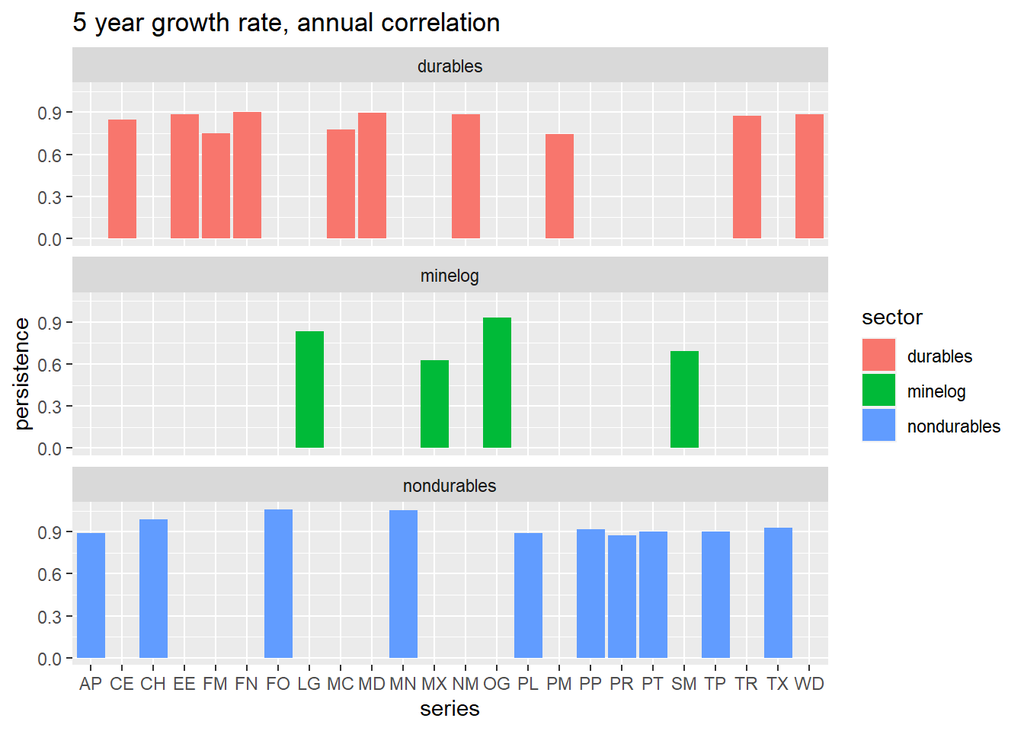

```r
p8b <- allcoefs2 %>% filter(measure == "D20L4") %>% ggplot(aes(x = series, y = persistence, fill = sector)) + geom_col() + labs(title = "5 year growth rate, annual correlation") + facet_wrap(~ sector, nrow = 3)
p8b
```

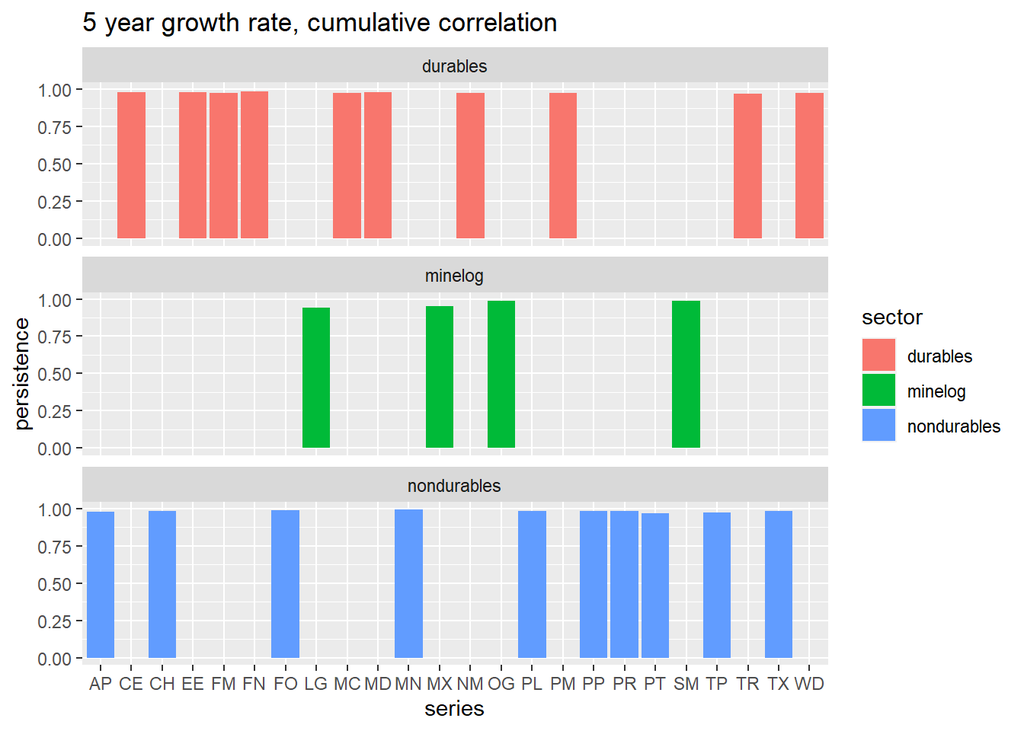

```r
p9b <- allcoefs2 %>% filter(measure == "D20L8") %>% ggplot(aes(x = series, y = persistence, fill = sector)) + geom_col() + labs(title = "5 year growth rate, cumulative correlation") + facet_wrap(~ sector, nrow = 3)
p9b
```